# Hyperoxia & Sepsis: Preliminary Report

### One year expire

```r
hs.oye.glm <- glm(oneyear_expire ~ hyperoxic_group + age + gender + ethnicity + icu_los + first_careunit +
                   vent_dur + oasis + elixhauser + vasopressor_flag,
                 family = binomial(link = "logit"), data = hs.eda.df %>% filter(hospital_expire == 0))
summary(hs.oye.glm)
```

```
##
## Call:
## glm(formula = oneyear_expire ~ hyperoxic_group + age + gender +
##     ethnicity + icu_los + first_careunit + vent_dur + oasis +
##     elixhauser + vasopressor_flag, family = binomial(link = "logit"),
##     data = hs.eda.df %>% filter(hospital_expire == 0))
##
## Deviance Residuals:
##     Min       1Q   Median       3Q      Max
## -1.7009  -0.7661  -0.5372   0.8010   2.8321
##
## Coefficients:
##                       Estimate Std. Error z value Pr(>|z|)
## (Intercept)         -5.6379387  0.4413122 -12.775  < 2e-16 ***
## hyperoxic_group2     0.1710571  0.1252286   1.366  0.17195
## hyperoxic_group3     0.3164790  0.1268453   2.495  0.01260 *
## hyperoxic_group4     0.0197182  0.1725522   0.114  0.90902
## age                  0.0412778  0.0033033  12.496  < 2e-16 ***
## gender1              0.2719260  0.0894002   3.042  0.00235 **
## ethnicityBLACK      -0.1958382  0.2991678  -0.655  0.51272
## ethnicityHISPANIC   -0.4664547  0.3980150  -1.172  0.24122
## ethnicityOTHER       0.1006070  0.2843270   0.354  0.72346
## ethnicityWHITE       0.1131447  0.2609124   0.434  0.66454
## icu_los              0.0005324  0.0005632   0.945  0.34451
## first_careunitCSRU  -0.9720121  0.1879255  -5.172 2.31e-07 ***
## first_careunitMICU   0.0073244  0.1391907   0.053  0.95803
## first_careunitSICU  -0.4343957  0.1584622  -2.741  0.00612 **
## first_careunitTSICU -0.4680245  0.1742349  -2.686  0.00723 **
## vent_dur             0.0007021  0.0009020   0.778  0.43634
## oasis                0.0314620  0.0063340   4.967 6.79e-07 ***
## elixhauser           0.1097015  0.0210276   5.217 1.82e-07 ***
## vasopressor_flag1   -0.2916270  0.0949394  -3.072  0.00213 **
## ---
## Signif. codes:  0 '***' 0.001 '**' 0.01 '*' 0.05 '.' 0.1 ' ' 1
##
## (Dispersion parameter for binomial family taken to be 1)
##
##     Null deviance: 3598.7  on 3191  degrees of freedom
## Residual deviance: 3174.7  on 3173  degrees of freedom
## AIC: 3212.7
##
## Number of Fisher Scoring iterations: 5
```

And now we can check the fit of this model.

```r
oye.glm.gof <- hoslem_gof(hs.oye.glm)
oye.glm.gof$p.value
```

```
## [1] 0.1082375
```

## EDA Part 2: Understanding the One-year Result

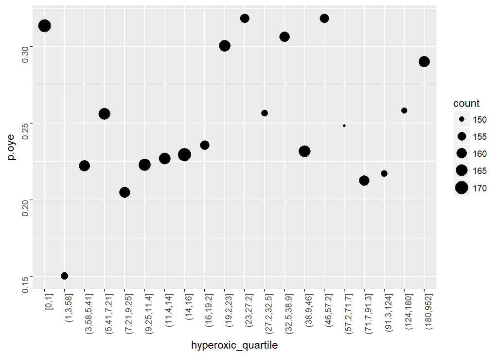

```r
hs.eda.df$hyperoxic_quartile <- with(hs.eda.df, cut(hyperoxic_dur,
                                breaks = quantile(hyperoxic_dur,
                                                  probs = seq(0,1, by = (1/20)),
                                                  na.rm=TRUE),
                                include.lowest = TRUE))


hs.eda.df %>% filter(hospital_expire == 0) %>% group_by(hyperoxic_quartile) %>%
  summarise(p.oye = mean(as.numeric(oneyear_expire == 1)), count = n()) %>%
  ggplot() + geom_point(aes(x = hyperoxic_quartile, y = p.oye, size = count)) +
  theme(axis.text = element_text(angle = 90, hjust = 1))
```

```r
hs.oye.glm <- glm(oneyear_expire ~ hyperoxic_quartile + age + gender + icu_los +
                   vent_dur + oasis + elixhauser + vasopressor_flag, family = binomial(link = "logit"), data = hs.eda.df %>% filter(hospital_expire == 0))
summary(hs.oye.glm)
```

```
##
## Call:
## glm(formula = oneyear_expire ~ hyperoxic_quartile + age + gender +
##     icu_los + vent_dur + oasis + elixhauser + vasopressor_flag,
##     family = binomial(link = "logit"), data = hs.eda.df %>% filter(hospital_expire ==
##         0))
##
## Deviance Residuals:
##     Min       1Q   Median       3Q      Max
## -1.6586  -0.7765  -0.5522   0.8246   2.6862
##
## Coefficients:
##                                 Estimate Std. Error z value Pr(>|z|)
## (Intercept)                   -5.6552099  0.3570204 -15.840  < 2e-16 ***
## hyperoxic_quartile(1,3.58]    -0.7732000  0.2960508  -2.612  0.00901 **
## hyperoxic_quartile(3.58,5.41] -0.3971902  0.2659861  -1.493  0.13537
## hyperoxic_quartile(5.41,7.21] -0.1571425  0.2592674  -0.606  0.54445
## hyperoxic_quartile(7.21,9.25] -0.6063515  0.2714398  -2.234  0.02549 *
## hyperoxic_quartile(9.25,11.4] -0.2280982  0.2659186  -0.858  0.39102
## hyperoxic_quartile(11.4,14]   -0.3752786  0.2658718  -1.412  0.15810
## hyperoxic_quartile(14,16]     -0.3414821  0.2609478  -1.309  0.19066
## hyperoxic_quartile(16,19.2]   -0.1094462  0.2664024  -0.411  0.68120
## hyperoxic_quartile(19.2,23]    0.0860078  0.2531238   0.340  0.73402
## hyperoxic_quartile(23,27.2]    0.1484298  0.2566045   0.578  0.56297
## hyperoxic_quartile(27.2,32.5] -0.1293111  0.2657656  -0.487  0.62657
## hyperoxic_quartile(32.5,38.9]  0.1235991  0.2572216   0.481  0.63086
## hyperoxic_quartile(38.9,46]   -0.2118787  0.2676549  -0.792  0.42859
## hyperoxic_quartile(46,57.2]    0.2337312  0.2632980   0.888  0.37470
## hyperoxic_quartile(57.2,71.7] -0.2620725  0.2806877  -0.934  0.35047
## hyperoxic_quartile(71.7,91.3] -0.3509472  0.2914043  -1.204  0.22846
## hyperoxic_quartile(91.3,124]  -0.4004152  0.3005053  -1.332  0.18270
## hyperoxic_quartile(124,180]   -0.0569630  0.3226471  -0.177  0.85986
## hyperoxic_quartile(180,952]    0.2345255  0.4281656   0.548  0.58387
## age                            0.0402996  0.0032549  12.381  < 2e-16 ***
## gender1                        0.2563703  0.0889128   2.883  0.00393 **
## icu_los                        0.0003849  0.0005579   0.690  0.49027
## vent_dur                      -0.0002462  0.0011166  -0.221  0.82547
## oasis                          0.0404555  0.0062116   6.513 7.37e-11 ***
## elixhauser                     0.1068668  0.0204078   5.237 1.64e-07 ***
## vasopressor_flag1             -0.3801329  0.0910005  -4.177 2.95e-05 ***
## ---
## Signif. codes:  0 '***' 0.001 '**' 0.01 '*' 0.05 '.' 0.1 ' ' 1
##
## (Dispersion parameter for binomial family taken to be 1)
##
##     Null deviance: 3598.7  on 3191  degrees of freedom
## Residual deviance: 3210.7  on 3165  degrees of freedom
## AIC: 3264.7
##
## Number of Fisher Scoring iterations: 4
```

```r
hs.oye.glm <- glm(oneyear_expire ~ rcs(hyperoxic_dur) + age + gender + icu_los + first_careunit + ethnicity +
                   vent_dur + oasis + elixhauser + vasopressor_flag, family = binomial(link = "logit"), data = hs.eda.df %>% filter(hospital_expire == 0))
summary(hs.oye.glm)
```

```
##
## Call:
## glm(formula = oneyear_expire ~ rcs(hyperoxic_dur) + age + gender +
##     icu_los + first_careunit + ethnicity + vent_dur + oasis +
##     elixhauser + vasopressor_flag, family = binomial(link = "logit"),
##     data = hs.eda.df %>% filter(hospital_expire == 0))
##
## Deviance Residuals:
##     Min       1Q   Median       3Q      Max
## -1.6573  -0.7693  -0.5341   0.8087   2.8676
##
## Coefficients:
##                                      Estimate Std. Error z value Pr(>|z|)
## (Intercept)                        -5.6266165  0.4557595 -12.346  < 2e-16
## rcs(hyperoxic_dur)hyperoxic_dur     0.0031703  0.0211312   0.150  0.88074
## rcs(hyperoxic_dur)hyperoxic_dur'    1.0143202  1.7682940   0.574  0.56623
## rcs(hyperoxic_dur)hyperoxic_dur''  -2.4466983  3.4503722  -0.709  0.47826
## rcs(hyperoxic_dur)hyperoxic_dur'''  1.7218217  1.8355971   0.938  0.34824
## age                                 0.0412314  0.0033037  12.480  < 2e-16
## gender1                             0.2737312  0.0894904   3.059  0.00222
## icu_los                             0.0004916  0.0005657   0.869  0.38487
## first_careunitCSRU                 -0.9726476  0.1879107  -5.176 2.27e-07
## first_careunitMICU                  0.0048441  0.1394091   0.035  0.97228
## first_careunitSICU                 -0.4367877  0.1585025  -2.756  0.00586
## first_careunitTSICU                -0.4722495  0.1744469  -2.707  0.00679
## ethnicityBLACK                     -0.2007026  0.2993494  -0.670  0.50256
## ethnicityHISPANIC                  -0.4639879  0.3980605  -1.166  0.24377
## ethnicityOTHER                      0.1068421  0.2846431   0.375  0.70740
## ethnicityWHITE                      0.1172761  0.2613065   0.449  0.65357
## vent_dur                            0.0011325  0.0014383   0.787  0.43106
## oasis                               0.0311467  0.0063385   4.914 8.93e-07
## elixhauser                          0.1090461  0.0210209   5.188 2.13e-07
## vasopressor_flag1                  -0.2936992  0.0949580  -3.093  0.00198
##
## (Intercept)                        ***
## rcs(hyperoxic_dur)hyperoxic_dur
## rcs(hyperoxic_dur)hyperoxic_dur'
## rcs(hyperoxic_dur)hyperoxic_dur''
## rcs(hyperoxic_dur)hyperoxic_dur'''
## age                                ***
```

[output cut: 9 more lines]

```
## ethnicityWHITE
## vent_dur
## oasis                              ***
## elixhauser                         ***
## vasopressor_flag1                  **
## ---
## Signif. codes:  0 '***' 0.001 '**' 0.01 '*' 0.05 '.' 0.1 ' ' 1
##
## (Dispersion parameter for binomial family taken to be 1)
##
##     Null deviance: 3598.7  on 3191  degrees of freedom
## Residual deviance: 3175.9  on 3172  degrees of freedom
## AIC: 3215.9
##
## Number of Fisher Scoring iterations: 5
```

## Nonlnearity?

Based on what we saw with one-year expiration above, lets examine hospital expiration for a non-linear association.

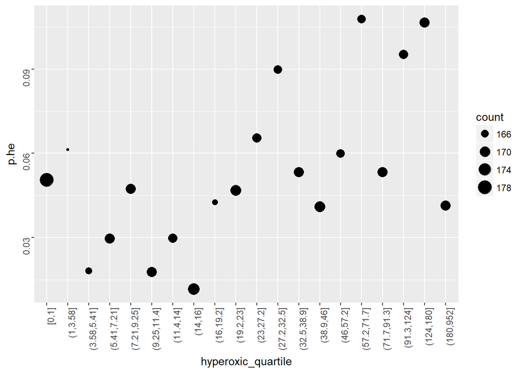

```r
hs.eda.df$hyperoxic_quartile <- with(hs.eda.df, cut(hyperoxic_dur,
                                breaks = quantile(hyperoxic_dur,
                                                  probs = seq(0,1, by = (1/20)),
                                                  na.rm=TRUE),
                                include.lowest = TRUE))


hs.eda.df %>% group_by(hyperoxic_quartile) %>%
  summarise(p.he = mean(as.numeric(hospital_expire == 1)), count = n()) %>%
  ggplot() + geom_point(aes(x = hyperoxic_quartile, y = p.he, size = count)) +
  #geom_smooth(aes(x = hyperoxic_quartile, y = (p.he/(1-p.he)), group =1)) +
  theme(axis.text = element_text(angle = 90, hjust = 1))
```

There appears to be a linear relationship, but significant noise.

```r
hs.he.glm <- glm(hospital_expire ~ rcs(hyperoxic_dur) + age + gender + ethnicity + first_careunit + icu_los +
                   vent_dur + oasis + elixhauser + vasopressor_flag,
                 family = binomial(link = "logit"), data = hs.eda.df)

summary(hs.he.glm)
```

```
##
## Call:
## glm(formula = hospital_expire ~ rcs(hyperoxic_dur) + age + gender +
##     ethnicity + first_careunit + icu_los + vent_dur + oasis +
##     elixhauser + vasopressor_flag, family = binomial(link = "logit"),
##     data = hs.eda.df)
##
## Deviance Residuals:
##     Min       1Q   Median       3Q      Max
## -1.1001  -0.3722  -0.2709  -0.1857   3.1666
##
## Coefficients:
##                                      Estimate Std. Error z value Pr(>|z|)
## (Intercept)                         -6.624519   0.900034  -7.360 1.83e-13
## rcs(hyperoxic_dur)hyperoxic_dur     -0.056699   0.040947  -1.385  0.16615
## rcs(hyperoxic_dur)hyperoxic_dur'     5.424642   3.215411   1.687  0.09159
## rcs(hyperoxic_dur)hyperoxic_dur''  -10.387490   6.183318  -1.680  0.09297
## rcs(hyperoxic_dur)hyperoxic_dur'''   5.325711   3.246000   1.641  0.10086
## age                                  0.031889   0.005912   5.394 6.90e-08
## gender1                              0.391978   0.160360   2.444  0.01451
## ethnicityBLACK                       0.565996   0.660992   0.856  0.39184
## ethnicityHISPANIC                    1.179959   0.722157   1.634  0.10227
## ethnicityOTHER                       1.239649   0.627008   1.977  0.04803
## ethnicityWHITE                       0.754300   0.604979   1.247  0.21246
## first_careunitCSRU                  -1.530881   0.471276  -3.248  0.00116
## first_careunitMICU                   0.209951   0.250080   0.840  0.40117
## first_careunitSICU                   0.230789   0.274623   0.840  0.40069
## first_careunitTSICU                 -0.542556   0.343336  -1.580  0.11405
## icu_los                             -0.002244   0.001206  -1.860  0.06283
## vent_dur                             0.005855   0.002286   2.561  0.01043
## oasis                                0.003093   0.011171   0.277  0.78187
## elixhauser                           0.064080   0.037079   1.728  0.08395
## vasopressor_flag1                    0.228239   0.165513   1.379  0.16790
##
## (Intercept)                        ***
## rcs(hyperoxic_dur)hyperoxic_dur
## rcs(hyperoxic_dur)hyperoxic_dur'   .
## rcs(hyperoxic_dur)hyperoxic_dur''  .
## rcs(hyperoxic_dur)hyperoxic_dur'''
## age                                ***
```

[output cut: 9 more lines]

```
## icu_los                            .
## vent_dur                           *
## oasis
## elixhauser                         .
## vasopressor_flag1
## ---
## Signif. codes:  0 '***' 0.001 '**' 0.01 '*' 0.05 '.' 0.1 ' ' 1
##
## (Dispersion parameter for binomial family taken to be 1)
##
##     Null deviance: 1405.1  on 3371  degrees of freedom
## Residual deviance: 1285.6  on 3352  degrees of freedom
## AIC: 1325.6
##
## Number of Fisher Scoring iterations: 7
```

Thankfully, restricted cubic splines don’t provide strong evidence for a non-linear relationship.

## Secondary Outcomes

Based on our table one, there was a difference between groups based on race; is race associated with hyperoxic time?

Lets begin with an anova.

```r
hd.eth.aov <- aov(hs.eda.df$hyperoxic_dur ~ hs.eda.df$ethnicity)
summary(hd.eth.aov)
```

```
##                       Df   Sum Sq Mean Sq F value   Pr(>F)
## hs.eda.df$ethnicity    4   131317   32829   6.007 8.18e-05 ***
## Residuals           3367 18402691    5466
## ---
## Signif. codes:  0 '***' 0.001 '**' 0.01 '*' 0.05 '.' 0.1 ' ' 1
```

There is a strong difference between the group means; however, we know that that hyperoxic duration is very skewed: we can make an argument via CLT, but since this is a secondary/exploratory outcome lets check it with a more robust method as well.

```r
hd.eth.aov <- kruskal.test(hs.eda.df$hyperoxic_dur ~ hs.eda.df$ethnicity)
print(hd.eth.aov)
```

```
##
##  Kruskal-Wallis rank sum test
##
## data:  hs.eda.df$hyperoxic_dur by hs.eda.df$ethnicity
## Kruskal-Wallis chi-squared = 25.694, df = 4, p-value = 3.647e-05
```

So race is clearly associated with how much time patients spend hyperoxic, but the question then is, could this be confounded by disease severity, comorbidity, and etc? Lets build a linear model to adjust for this.

```r
hd.eth.lm <- lm(hyperoxic_dur ~ ethnicity + age + gender + first_careunit +
                  icu_los + vent_dur + oasis + elixhauser + vasopressor_flag,
                data = hs.eda.df)
summary(hd.eth.lm)
```

```
##
## Call:
## lm(formula = hyperoxic_dur ~ ethnicity + age + gender + first_careunit +
##     icu_los + vent_dur + oasis + elixhauser + vasopressor_flag,
##     data = hs.eda.df)
##
## Residuals:
##      Min       1Q   Median       3Q      Max
## -214.769   -6.882    3.420    9.941  195.349
##
## Coefficients:
##                      Estimate Std. Error t value Pr(>|t|)
## (Intercept)          5.708442   4.096501   1.393 0.163563
## ethnicityBLACK       1.202311   3.083784   0.390 0.696649
## ethnicityHISPANIC   -5.754145   3.657637  -1.573 0.115770
## ethnicityOTHER      -8.566360   2.931516  -2.922 0.003499 **
## ethnicityWHITE      -9.349512   2.725257  -3.431 0.000609 ***
## age                 -0.064431   0.029478  -2.186 0.028903 *
## gender1             -3.389766   0.900761  -3.763 0.000171 ***
## first_careunitCSRU   4.502792   1.860162   2.421 0.015546 *
## first_careunitMICU   0.223819   1.543993   0.145 0.884750
## first_careunitSICU   3.031190   1.683325   1.801 0.071838 .
## first_careunitTSICU  5.407363   1.817378   2.975 0.002947 **
## icu_los             -0.001704   0.005863  -0.291 0.771415
## vent_dur             0.710421   0.008518  83.399  < 2e-16 ***
## oasis                0.045626   0.064131   0.711 0.476855
## elixhauser          -0.022141   0.216431  -0.102 0.918525
## vasopressor_flag1    1.174673   0.965511   1.217 0.223830
## ---
## Signif. codes:  0 '***' 0.001 '**' 0.01 '*' 0.05 '.' 0.1 ' ' 1
##
## Residual standard error: 25.84 on 3356 degrees of freedom
## Multiple R-squared:  0.8791, Adjusted R-squared:  0.8785
## F-statistic:  1626 on 15 and 3356 DF,  p-value: < 2.2e-16
```

There is a very strong signal for ethnicity, and ~87.85% of the variance is explained. However, we should check our model.

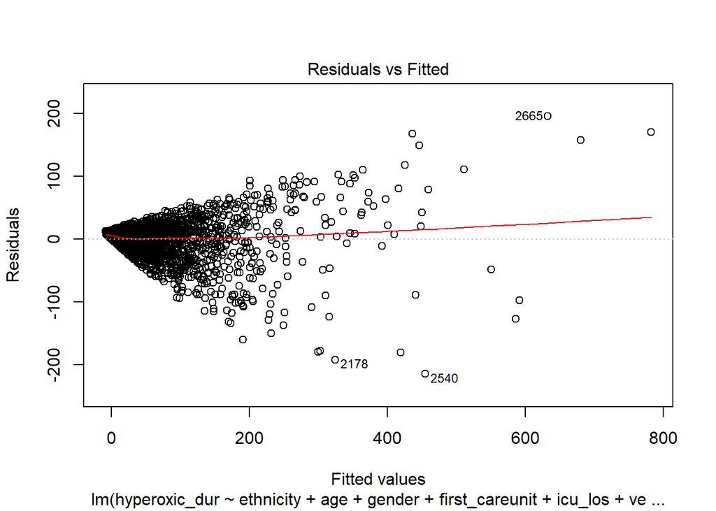

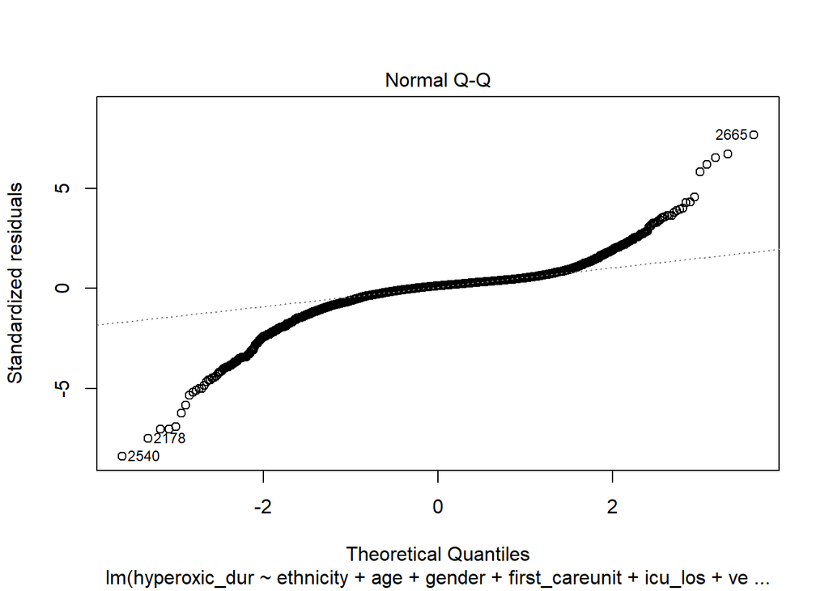

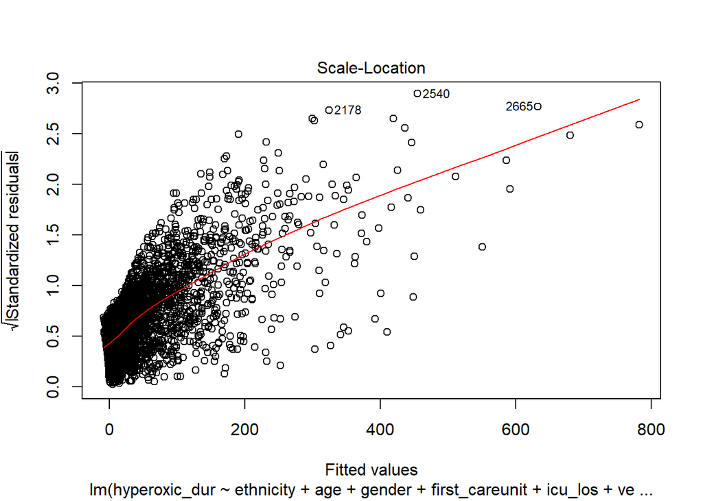

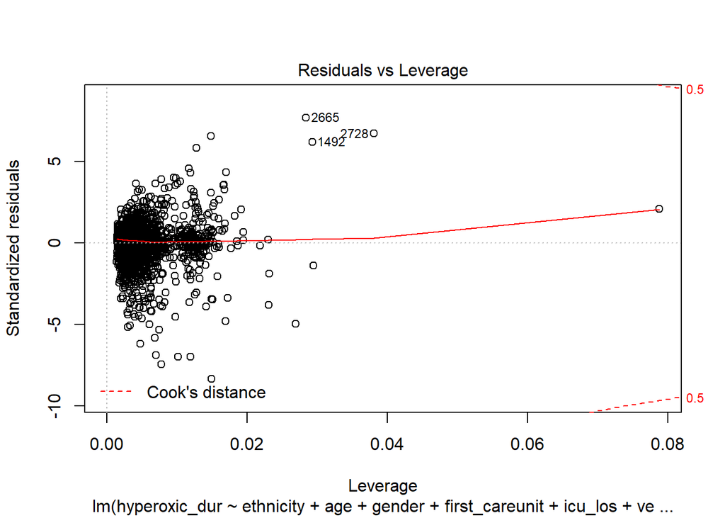

```r
p <- plot(hd.eth.lm)
```

Unfortunately, based one the residuals, the assumptions of regression do not hold. I hypothesize that this is a result of the massive skew in the hyperoxic durations. Perhaps we should use median regression.

```r
hd.eth.lm <- rq(hyperoxic_dur ~ ethnicity + age + gender + first_careunit +
                  icu_los + vent_dur + oasis + elixhauser + vasopressor_flag,
                tau = 0.5,
                data = hs.eda.df)
summary(hd.eth.lm)
```

```
##
## Call: rq(formula = hyperoxic_dur ~ ethnicity + age + gender + first_careunit +
##     icu_los + vent_dur + oasis + elixhauser + vasopressor_flag,
##     tau = 0.5, data = hs.eda.df)
##
## tau: [1] 0.5
##
## Coefficients:
##                     Value    Std. Error t value  Pr(>|t|)
## (Intercept)          4.75908  1.74574    2.72612  0.00644
## ethnicityBLACK      -1.36480  1.25147   -1.09056  0.27555
## ethnicityHISPANIC   -3.71122  1.42584   -2.60283  0.00929
## ethnicityOTHER      -6.47119  1.12437   -5.75541  0.00000
## ethnicityWHITE      -4.82706  0.97943   -4.92843  0.00000
## age                 -0.04323  0.01303   -3.31838  0.00092
## gender1             -1.95962  0.37247   -5.26113  0.00000
## first_careunitCSRU   3.24267  0.70391    4.60668  0.00000
## first_careunitMICU   0.44046  0.81073    0.54328  0.58697
## first_careunitSICU   3.09737  0.78985    3.92146  0.00009
## first_careunitTSICU  4.08290  0.68875    5.92803  0.00000
## icu_los             -0.00099  0.00356   -0.27916  0.78014
## vent_dur             0.71009  0.01358   52.29120  0.00000
## oasis                0.03705  0.02594    1.42853  0.15323
## elixhauser          -0.08266  0.10330   -0.80018  0.42366
## vasopressor_flag1    0.57394  0.41028    1.39890  0.16194
```

Also noteable is that gender is independenlty associated with hyperoxic duration with a very strong signal. Woman appear to be recieving more titration. Both of these associations could be related to the prevalence of disease processes in these patients; we aren’t excluding any specific diagnoses.